# qta_hilton-lam_homework01

## Analysing Irish Political Party Manifestos With NLP Methods

Author: Hilton Lam

Date: Feb 2025

## Data Exploration

```r
library(quanteda)
library(dplyr)
# Change working directory to my folder in R terminal
setwd("/Users/hiltonlam/Documents/GitHub/nlp-project-1")

data_ie_corpus <- read.csv("Ireland_Corpus2.0.csv")

#  Preview the dataset
str(data_ie_corpus)
```

```
'data.frame':   18286 obs. of  8 variables:
 $ country    : int  53 53 53 53 53 53 53 53 53 53 ...
 $ countryname: chr  "Ireland" "Ireland" "Ireland" "Ireland" ...
 $ sentence_id: int  1 2 3 4 5 6 7 8 9 10 ...
 $ text       : chr  "Aontú is Ireland’s fastest growing political movement" "We stand for Economic Justice, Irish unity and a society where every individual is valued." "Our country should not be a place where anyone is deemed of less innate worth for any reason." "We seek to break the stifling gro…
 $ date       : int  202002 202002 202002 202002 202002 202002 202002 202002 202002 202002 ...
 $ party      : int  53952 53952 53952 53952 53952 53952 53952 53952 53952 53952 ...
 $ partyname  : chr  "Aontú" "Aontú" "Aontú" "Aontú" ...
 $ text_id    : chr  "53952_202002_1" "53952_202002_2" "53952_202002_3" "53952_202002_4" ...
```

```r
unique(data_ie_corpus$date)
```

```
[1] 202002 202411
```

```r
# Count number of manifestos by party and date
num_manifestos <- data_ie_corpus |>
    distinct(partyname, date) |>
    count(partyname, date)

print(num_manifestos) # There are 10 manifestos in total, 9 manifestos for 9 parties in 2024 and 1 more for Aontu in 2020
```

```
              partyname   date n
1                 Aontú 202002 1
2                 Aontú 202411 1
3           Fianna Fáil 202411 1
4             Fine Gael 202411 1
5                Greens 202411 1
6   Independent Ireland 202411 1
7                Labour 202411 1
8  People Before Profit 202411 1
9             Sinn Féin 202411 1
10     Social Democrats 202411 1
```

```r
# Turn the dataframe into text corpus
ie_corpus <- corpus(
    data_ie_corpus
    ,text_field = "text"
)

# Filter to only 2024 manifestos
ie_corpus_2024 <- corpus_subset(
    ie_corpus,
    date == "202411"
)

# check out the corpus
str(ie_corpus_2024)
```

```
 'corpus' Named chr [1:17212] "More and Better Homes" ...
 - attr(*, "names")= chr [1:17212] "text1075" "text1076" "text1077" "text1078" ...
 - attr(*, "docvars")='data.frame': 17212 obs. of  10 variables:
  ..$ docname_   : chr [1:17212] "text1075" "text1076" "text1077" "text1078" ...
  ..$ docid_     : Factor w/ 17212 levels "text1075","text1076",..: 1 2 3 4 5 6 7 8 9 10 ...
  ..$ segid_     : int [1:17212] 1 1 1 1 1 1 1 1 1 1 ...
  ..$ country    : int [1:17212] 53 53 53 53 53 53 53 53 53 53 ...
  ..$ countryname: chr [1:17212] "Ireland" "Ireland" "Ireland" "Ireland" ...
  ..$ sentence_id: int [1:17212] 1 2 3 4 5 6 7 8 9 10 ...
  ..$ date       : int [1:17212] 202411 202411 202411 202411 202411 202411 202411 202411 202411 202411 ...
  ..$ party      : int [1:17212] 53110 53110 53110 53110 53110 53110 53110 53110 53110 53110 ...
  ..$ partyname  : chr [1:17212] "Greens" "Greens" "Greens" "Greens" ...
  ..$ text_id    : chr [1:17212] "53110_202411_1" "53110_202411_2" "53110_202411_3" "53110_202411_4" ...
 - attr(*, "meta")=List of 3
  ..$ system:List of 5
  .. ..$ package-version:Classes 'package_version', 'numeric_version'  hidden list of 1
  .. .. ..$ : int [1:3] 4 2 0
  .. ..$ r-version      :Classes 'R_system_version', 'package_version', 'numeric_version'  hidden list of 1
  .. .. ..$ : int [1:3] 4 4 2
  .. ..$ system         : Named chr [1:3] "Darwin" "arm64" "hiltonlam"
  .. .. ..- attr(*, "names")= chr [1:3] "sysname" "machine" "user"
  .. ..$ directory      : chr "/Users/hiltonlam/Documents/GitHub/nlp-project-1"
  .. ..$ created        : Date[1:1], format: "2025-04-08"
  ..$ object:List of 2
  .. ..$ unit   : chr "documents"
  .. ..$ summary:List of 2
  .. .. ..$ hash: chr(0)
  .. .. ..$ data: NULL
  ..$ user  : list()
```

## Corpus Pre-Processing

Create a dictionary on terms and phrases related to housing policy

```r
# create a dictionary using the link above and ChatGPT for identifying the terms
housing_dict <- dictionary(list(
housing = c("rental", "property sale", "housing rental", "rental housing", "housing for sale","affordable purchase scheme","social housing","approved housing bodies","cost rental","housing assistance payment","housing assistance","housing support","housing policy","housing plan","housing strategy","housing development","housing construction","housing supply","housing demand","housing crisis","housing shortage","housing affordability","differential rent","first home scheme","help to buy","housing assistance","local authority home","mortgage to rent","rental accommodation","rent supplement")))

# check out structure
housing_dict
```

```
Dictionary object with 1 key entry.
- [housing]:
  - rental, property sale, housing rental, rental housing, housing for sale, affordable purchase scheme, social housing, approved housing bodies, cost rental, housing assistance payment, housing assistance, housing support, housing policy, housing plan, housing strategy, housing development, housing…
```

Number of sentences per manifesto

```r
library(dplyr)

# To understand the data structure again. I can now see that each line/document is actually one sentence, represented by sentence_id. Since each party only has one manifesto, then I can count the number of sentences per manifesto that way.
str(ie_corpus_2024)
```

```
 'corpus' Named chr [1:17212] "More and Better Homes" ...
 - attr(*, "names")= chr [1:17212] "text1075" "text1076" "text1077" "text1078" ...
 - attr(*, "docvars")='data.frame': 17212 obs. of  10 variables:
  ..$ docname_   : chr [1:17212] "text1075" "text1076" "text1077" "text1078" ...
  ..$ docid_     : Factor w/ 17212 levels "text1075","text1076",..: 1 2 3 4 5 6 7 8 9 10 ...
  ..$ segid_     : int [1:17212] 1 1 1 1 1 1 1 1 1 1 ...
  ..$ country    : int [1:17212] 53 53 53 53 53 53 53 53 53 53 ...
  ..$ countryname: chr [1:17212] "Ireland" "Ireland" "Ireland" "Ireland" ...
  ..$ sentence_id: int [1:17212] 1 2 3 4 5 6 7 8 9 10 ...
  ..$ date       : int [1:17212] 202411 202411 202411 202411 202411 202411 202411 202411 202411 202411 ...
  ..$ party      : int [1:17212] 53110 53110 53110 53110 53110 53110 53110 53110 53110 53110 ...
  ..$ partyname  : chr [1:17212] "Greens" "Greens" "Greens" "Greens" ...
  ..$ text_id    : chr [1:17212] "53110_202411_1" "53110_202411_2" "53110_202411_3" "53110_202411_4" ...
 - attr(*, "meta")=List of 3
  ..$ system:List of 5
  .. ..$ package-version:Classes 'package_version', 'numeric_version'  hidden list of 1
  .. .. ..$ : int [1:3] 4 2 0
  .. ..$ r-version      :Classes 'R_system_version', 'package_version', 'numeric_version'  hidden list of 1
  .. .. ..$ : int [1:3] 4 4 2
  .. ..$ system         : Named chr [1:3] "Darwin" "arm64" "hiltonlam"
  .. .. ..- attr(*, "names")= chr [1:3] "sysname" "machine" "user"
  .. ..$ directory      : chr "/Users/hiltonlam/Documents/GitHub/nlp-project-1"
  .. ..$ created        : Date[1:1], format: "2025-04-08"
  ..$ object:List of 2
  .. ..$ unit   : chr "documents"
  .. ..$ summary:List of 2
  .. .. ..$ hash: chr(0)
  .. .. ..$ data: NULL
  ..$ user  : list()
```

```r
# Convert the corpus to a data frame
df_corpus <- convert(ie_corpus_2024, to = "data.frame")

# Count the number of sentences per party
sentence_counts <- df_corpus %>%
  group_by(partyname) %>%
  count(name = "sentence_count") %>%
  arrange(desc(sentence_count))

sentence_counts
```

```
# A tibble: 9 × 2
# Groups:   partyname [9]
  partyname            sentence_count
  <chr>                         <int>
1 Labour                         3062
2 Social Democrats               2953
3 Fine Gael                      2607
4 Sinn Féin                      2307
5 Fianna Fáil                    1923
6 Greens                         1588
7 Aontú                          1501
8 People Before Profit            799
9 Independent Ireland             472
```

*Therefore, we can see that the manifesto with the highest number of sentences is Labour and the lowest is Independent Ireland.*

Tokenize the corpus without any preprocessing.

```r
toks_noprocessing <- tokens(ie_corpus_2024)
```

Apply the dictionary created above to the tokens object of Irish party manifestos, then create a dfm.

```r
# Check that the dictionary works properly
# kwic(toks_noprocessing, pattern = phrase(housing_dict))

# Apply the dictionary to the tokens object using tokens_lookup
tokens_housing <- tokens_lookup(toks_noprocessing, dictionary = housing_dict, nested_scope = "dictionary")

# Create a dfm from the tokens object
dfm_housing <- dfm(tokens_housing)
```

Apply Boolean weighting to the dfm and convert to a data frame.

```r
dfm_boolean <- dfm_weight(dfm_housing, scheme = "boolean")

# Convert dfm to a data frame
dfm_df <- convert(dfm_boolean, to = "data.frame")
```

Aggregate the scores to the level of manifestos and then calculate the mean of the housing variable from the data frame.

```r
# Aggregate the sum of the housing column by partyname and date in df_corpus

housing_mention_agg <-
  left_join(df_corpus, dfm_df, by = "doc_id") |>
  group_by(partyname, date) |>
  summarise(total_housing = sum(housing, na.rm = TRUE))
# head(dfm_df)

# View the aggregated housing data
print(housing_mention_agg)
```

```
# A tibble: 9 × 3
# Groups:   partyname [9]
  partyname              date total_housing
  <chr>                 <int>         <dbl>
1 Aontú                202411            12
2 Fianna Fáil          202411            14
3 Fine Gael            202411            40
4 Greens               202411            20
5 Independent Ireland  202411            10
6 Labour               202411            79
7 People Before Profit 202411            11
8 Sinn Féin            202411            31
9 Social Democrats     202411            22
```

## Data Visualisation

Create a plot to housing mentions by party.

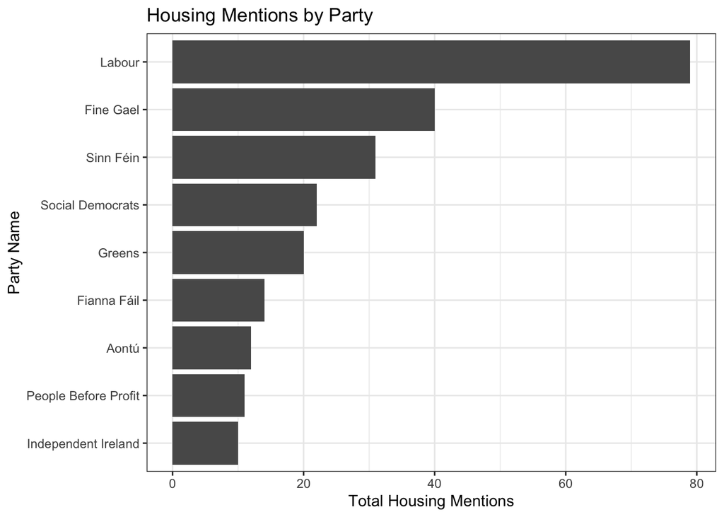

```r
library(ggplot2)

# Create a bar chart
ggplot(housing_mention_agg, aes(x = total_housing, y = reorder(partyname, total_housing))) +
  geom_bar(stat = "identity") +
  labs(
    title = "Housing Mentions by Party",
    x = "Total Housing Mentions",
    y = "Party Name"
  ) +
  theme_bw()
```

*From this plot, we can see that the Labour party has the highest number of housing mentions in 2024, followed by the Fine Gael and Sinn Fein.*

## Sentiment Analysis

Apply the Lexicoder Sentiment Dictionary (`data_dictionary_LSD2015`, included in **quanteda**) to the sentence-level party manifestos. Then I will use the formula suggested by Proksch et al. (2019, Legislative Studies Quarterly) to calculate a sentiment score for each sentence.

```r
df_sentiment <- toks_noprocessing |>
    tokens_lookup(dictionary = data_dictionary_LSD2015, nested_scope = "dictionary") |>
    dfm() |>
    convert(to = "data.frame")

# Caculate the sentiment score
df_sentiment <- df_sentiment |>
  mutate(sentiment = log((positive + neg_negative + 0.5) /
  (negative + neg_positive + 0.5)))

head(df_sentiment, 5)
```

```
    doc_id negative positive neg_positive neg_negative  sentiment
1 text1075        0        1            0            0  1.0986123
2 text1076        2        0            0            0 -1.6094379
3 text1077        3        1            0            0 -0.8472979
4 text1078        0        2            0            0  1.6094379
5 text1079        2        1            0            0 -0.5108256
```

Merge the data frame from the previous question with the data frame created previously to get more meta data.

```r
library(dplyr)

# Convert housing dfm to df
df_housing <- convert(dfm_housing, to = "data.frame")
# head(df_housing)

# Merge the dataframes
merged_df <- left_join(df_housing, df_sentiment, by = "doc_id")

head(merged_df)
```

```
    doc_id housing negative positive neg_positive neg_negative  sentiment
1 text1075       0        0        1            0            0  1.0986123
2 text1076       0        2        0            0            0 -1.6094379
3 text1077       0        3        1            0            0 -0.8472979
4 text1078       0        0        2            0            0  1.6094379
5 text1079       1        2        1            0            0 -0.5108256
6 text1080       1        1        1            0            0  0.0000000
```

## Linear Regression to Predict Sentiment Score

Transform the binary indicator of housing (1/0) into a factor variable, housing_factor, taking the value “Housing” when the variable takes the value 1 and “Other Policy Area” if the value is 0.

Run a linear regression model to predict the sentence-level sentiment score.

```r
# Transform the binary indicator of housing into a factor variable
merged_df$housing_factor <- factor(merged_df$housing, levels = c(0, 1), labels = c("Other Policy Area", "Housing"))
head(merged_df)
```

```
    doc_id housing negative positive neg_positive neg_negative  sentiment
1 text1075       0        0        1            0            0  1.0986123
2 text1076       0        2        0            0            0 -1.6094379
3 text1077       0        3        1            0            0 -0.8472979
4 text1078       0        0        2            0            0  1.6094379
5 text1079       1        2        1            0            0 -0.5108256
6 text1080       1        1        1            0            0  0.0000000
     housing_factor
1 Other Policy Area
2 Other Policy Area
3 Other Policy Area
4 Other Policy Area
5           Housing
6           Housing
```

```r
# Display the unique values (levels) in the factor housing_factor
unique_levels <- levels(merged_df$housing_factor)
print(unique_levels)
```

```
[1] "Other Policy Area" "Housing"
```

```r
# Select only the doc_id and partyname columns from df_corpus
df_corpus_selected <- df_corpus |> select(doc_id, partyname)

# Merge the data frames using left_join
merged_df <- left_join(merged_df, df_corpus_selected, by = "doc_id")

# Rename the column from partyname to manifesto
merged_df <- merged_df |> rename(manifesto = partyname)

# Check the structure of the merged data frame
str(merged_df)
```

```
'data.frame':   17212 obs. of  9 variables:
 $ doc_id        : chr  "text1075" "text1076" "text1077" "text1078" ...
 $ housing       : num  0 0 0 0 1 1 0 0 0 0 ...
 $ negative      : num  0 2 3 0 2 1 0 0 1 0 ...
 $ positive      : num  1 0 1 2 1 1 1 1 1 0 ...
 $ neg_positive  : num  0 0 0 0 0 0 0 0 0 0 ...
 $ neg_negative  : num  0 0 0 0 0 0 0 0 0 0 ...
 $ sentiment     : num  1.099 -1.609 -0.847 1.609 -0.511 ...
 $ housing_factor: Factor w/ 2 levels "Other Policy Area",..: 1 1 1 1 2 2 1 1 1 1 ...
 $ manifesto     : chr  "Greens" "Greens" "Greens" "Greens" ...
```

```r
head(merged_df)
```

```
    doc_id housing negative positive neg_positive neg_negative  sentiment
1 text1075       0        0        1            0            0  1.0986123
2 text1076       0        2        0            0            0 -1.6094379
3 text1077       0        3        1            0            0 -0.8472979
4 text1078       0        0        2            0            0  1.6094379
5 text1079       1        2        1            0            0 -0.5108256
6 text1080       1        1        1            0            0  0.0000000
     housing_factor manifesto
1 Other Policy Area    Greens
2 Other Policy Area    Greens
3 Other Policy Area    Greens
4 Other Policy Area    Greens
5           Housing    Greens
6           Housing    Greens
```

```r
# Change the manifesto variable to a factor
merged_df$manifesto <- factor(merged_df$manifesto)

# See all unique values
unique_levels <- levels(merged_df$manifesto)
print(unique_levels)
```

```
[1] "Aontú"                "Fianna Fáil"          "Fine Gael"
[4] "Greens"               "Independent Ireland"  "Labour"
[7] "People Before Profit" "Sinn Féin"            "Social Democrats"
```

```r
# Run a linear regression model with manifesto fixed effects
model <- lm(sentiment ~ housing_factor + manifesto, data = merged_df)
```

Output of the regression model

```r
summary(model)
```

```
Call:
lm(formula = sentiment ~ housing_factor + manifesto, data = merged_df)

Residuals:
    Min      1Q  Median      3Q     Max
-3.4654 -0.5762  0.0053  0.7239  2.9351

Coefficients:
                              Estimate Std. Error t value Pr(>|t|)
(Intercept)                   -0.10185    0.02630  -3.873 0.000108 ***
housing_factorHousing          0.05655    0.07100   0.796 0.425771
manifestoFianna Fáil           0.61773    0.03510  17.598  < 2e-16 ***
manifestoFine Gael             1.00230    0.03302  30.355  < 2e-16 ***
manifestoGreens                0.63557    0.03669  17.325  < 2e-16 ***
manifestoIndependent Ireland   0.44364    0.05384   8.240  < 2e-16 ***
manifestoLabour                0.67802    0.03213  21.105  < 2e-16 ***
manifestoPeople Before Profit  0.09655    0.04461   2.164 0.030450 *
manifestoSinn Féin             0.47661    0.03379  14.105  < 2e-16 ***
manifestoSocial Democrats      0.56733    0.03229  17.568  < 2e-16 ***
---
Signif. codes:  0 '***' 0.001 '**' 0.01 '*' 0.05 '.' 0.1 ' ' 1

Residual standard error: 1.019 on 17172 degrees of freedom
  (30 observations deleted due to missingness)
Multiple R-squared:  0.06446,   Adjusted R-squared:  0.06397
F-statistic: 131.5 on 9 and 17172 DF,  p-value: < 2.2e-16
```

## Cleaning up misclassified keywords

This model has a very low R-squared (0.06446), indicating that the model explains very little variance in sentiment.

However, the manifesto fixed effects are statistically significant, indicating that the sentiment score varies across different manifestos. The manifesto factor is a better indicator of sentence-level sentiment than housing factor._

Use `tokens_keep()` to select only negative terms from “toks_noprocessing” (`data_dictionary_LS2015$negative`). Then transform the object to a dfm and get the 100 most frequent negative terms. Identify terms that have been misclassified in this context.

```r
tokens_negative <- tokens_keep(toks_noprocessing, pattern = data_dictionary_LSD2015$negative)

#  Transform the tokens object to a dfm
dfm_negative <- dfm(tokens_negative)

# Get the 100 most frequent negative terms
top_negative_terms <- topfeatures(dfm_negative, 100)

# See output
print(top_negative_terms)
```

```
           ireland          ireland’s         disability            poverty
              1121                366                259                180
      disabilities             crisis            against         challenges
               172                152                134                131
             crime                too              waste           violence
               105                104                102                101
         emergency           critical           criminal               risk
                95                 92                 88                 86
        vulnerable           disabled            victims          oversight
                75                 73                 71                 68
             abuse       homelessness               lack             cancer
                66                 62                 61                 61
            double             prison            charges            illegal
                60                 58                 52                 51
           abolish             failed              limit     discrimination
                51                 50                 47                 45
               war            failure       disadvantage           conflict
                45                 43                 42                 40
            oppose             damage               loss             burden
                40                 38                 37                 37
         addiction           homeless      disadvantaged             forced
                37                 36                 36                 36
              poor           affected             limits          pollution
                36                 34                 33                 33
            delays             combat          challenge              avoid
                33                 33                 32                 32
            crimes            threats         inequality        deprivation
                31                 31                 31                 31
           problem           problems             charge          penalties
                30                 28                 28                 28
          dementia              risks            limited          difficult
                27                 26                 26                 25
         exclusion         artificial           shortage               hate
                25                 24                 24                 24
             fraud         struggling          eliminate         wastewater
                24                 23                 23                 23
         suffering             threat              fight          defective
                23                 23                 23                 22
     unprecedented           invasion          shortages           negative
                22                 21                 21                 21
      exploitation          excessive         abolishing             severe
                21                 21                 20                 20
           cutting             deaths            deficit          dangerous
                20                 20                 20                 20
          excluded            extreme               debt         precarious
                19                 19                 19                 19
disproportionately       difficulties             racism            harmful
                19                 18                 18                 18
           disease          disregard           struggle              worst
                18                 18                 18                 18
```

Remove the terms that do not express positive or negative sentiment from the “toks_noprocessing” tokens object (using `tokens_remove()`), apply the dictionary again, and repeat the steps above to review the output of the regression model.

```r
# See the top positive terms
tokens_positive <- tokens_keep(toks_noprocessing, pattern = data_dictionary_LSD2015$positive)
dfm_positive <- dfm(tokens_positive)
top_positive_terms <- topfeatures(dfm_positive, 100)
print(top_positive_terms)
```

```
        ensure        support           care        provide       ensuring
          1383           1321            701            694            372
      supports         rights        improve    sustainable         create
           333            320            318            269            266
          free     supporting     affordable         better      resources
           250            246            235            234            233
       enhance     protection          right  accommodation        protect
           226            224            214            202            198
          help        quality      providing        benefit         safety
           197            189            173            172            165
     dedicated           like  opportunities     strengthen    significant
           163            161            161            157            156
       special      essential      encourage           fair           well
           154            145            140            140            136
 comprehensive     accessible           best         credit          vital
           130            125            124            124            119
      equality           safe         secure       progress        achieve
           118            115            115            115            115
     improving         strong     innovation       benefits           good
           112            112            109            106             98
accountability    educational     commitment      effective responsibility
            97             97             93             90             90
      creating         active       learning      supported          civil
            89             87             84             83             80
          open            aid sustainability         wealth      voluntary
            78             77             75             75             74
    protecting       stronger         foster        efforts     assistance
            73             73             73             68             66
       restore      agreement       improved       adequate       properly
            66             66             66             65             65
   restoration     neutrality         vision     efficiency      enhancing
            64             64             62             62             62
      enhanced     adequately      protected        advance         relief
            61             59             57             55             55
  contribution     successful       relevant  contributions       positive
            55             53             53             53             52
   responsible        credits         assist       advocate    effectively
            51             51             51             50             50
     efficient        forward        balance     incentives         robust
            50             50             49             49             49
```

```r
# A list of terms that shouldn't be classified as positive or negative
non_sentiment_terms <- c("ireland", "ireland's", "artificial", "neutrality")

# Remove those terms
toks_cleaned <- tokens_remove(toks_noprocessing, pattern = non_sentiment_terms)

# Apply sentiment dictionary
df_sentiment_cleaned <- toks_cleaned |>
    tokens_lookup(dictionary = data_dictionary_LSD2015, nested_scope = "dictionary") |>
    dfm() |>
    convert(to = "data.frame")

# Calculate the sentiment score
df_sentiment_cleaned <- df_sentiment_cleaned |>
  mutate(sentiment = log((positive + neg_negative + 0.5) /
  (negative + neg_positive + 0.5)))

# head(df_sentiment_cleaned)

# Merged the dataframes
merged_df_cleaned <- left_join(df_sentiment_cleaned, df_corpus_selected, by = "doc_id")

# Add the housing_factor from merged_df (previous df) to merged_df_cleaned with cleaned up keywords
merged_df_cleaned <- left_join(merged_df_cleaned, merged_df |> select(doc_id, housing_factor), by = "doc_id")

# Rename partyname to manifesto
merged_df_cleaned <- merged_df_cleaned |> rename(manifesto = partyname)

# Convert the manifesto variable to a factor
merged_df_cleaned$manifesto <- factor(merged_df_cleaned$manifesto)

# Preview the datasaet
head(merged_df_cleaned)
```

```
    doc_id negative positive neg_positive neg_negative  sentiment manifesto
1 text1075        0        1            0            0  1.0986123    Greens
2 text1076        2        0            0            0 -1.6094379    Greens
3 text1077        3        1            0            0 -0.8472979    Greens
4 text1078        0        2            0            0  1.6094379    Greens
5 text1079        2        1            0            0 -0.5108256    Greens
6 text1080        1        1            0            0  0.0000000    Greens
     housing_factor
1 Other Policy Area
2 Other Policy Area
3 Other Policy Area
4 Other Policy Area
5           Housing
6           Housing
```

```r
str(merged_df_cleaned)
```

```
'data.frame':   17212 obs. of  8 variables:
 $ doc_id        : chr  "text1075" "text1076" "text1077" "text1078" ...
 $ negative      : num  0 2 3 0 2 1 0 0 1 0 ...
 $ positive      : num  1 0 1 2 1 1 1 1 1 0 ...
 $ neg_positive  : num  0 0 0 0 0 0 0 0 0 0 ...
 $ neg_negative  : num  0 0 0 0 0 0 0 0 0 0 ...
 $ sentiment     : num  1.099 -1.609 -0.847 1.609 -0.511 ...
 $ manifesto     : Factor w/ 9 levels "Aontú","Fianna Fáil",..: 4 4 4 4 4 4 4 4 4 4 ...
 $ housing_factor: Factor w/ 2 levels "Other Policy Area",..: 1 1 1 1 2 2 1 1 1 1 ...
```

```r
# Run the linear regression model
model_cleaned <- lm(sentiment ~ housing_factor + manifesto, data = merged_df_cleaned)

# Summarize the model
summary(model_cleaned)
```

```
Call:
lm(formula = sentiment ~ housing_factor + manifesto, data = merged_df_cleaned)

Residuals:
    Min      1Q  Median      3Q     Max
-3.5430 -0.6315  0.0504  0.6793  2.8836

Coefficients:
                              Estimate Std. Error t value Pr(>|t|)
(Intercept)                   -0.05038    0.02622  -1.921   0.0547 .
housing_factorHousing          0.01872    0.07078   0.265   0.7914
manifestoFianna Fáil           0.62057    0.03500  17.732   <2e-16 ***
manifestoFine Gael             1.02838    0.03292  31.240   <2e-16 ***
manifestoGreens                0.62492    0.03658  17.086   <2e-16 ***
manifestoIndependent Ireland   0.45008    0.05368   8.384   <2e-16 ***
manifestoLabour                0.68188    0.03203  21.289   <2e-16 ***
manifestoPeople Before Profit  0.08581    0.04447   1.929   0.0537 .
manifestoSinn Féin             0.46969    0.03369  13.942   <2e-16 ***
manifestoSocial Democrats      0.57741    0.03220  17.935   <2e-16 ***
---
Signif. codes:  0 '***' 0.001 '**' 0.01 '*' 0.05 '.' 0.1 ' ' 1

Residual standard error: 1.016 on 17172 degrees of freedom
  (30 observations deleted due to missingness)
Multiple R-squared:  0.06825,   Adjusted R-squared:  0.06777
F-statistic: 139.8 on 9 and 17172 DF,  p-value: < 2.2e-16
```

## Keyness analysis

Create a new document-level variable that takes the values “FF/FG” for Fianna Fáil and Fine Gael manifestos, and the value “Other Parties” for all other manifestos. Tokenize this text corpus. Then create a dfm, and group this dfm by the new document-level variable (ffg_other).

```r
# Create a new document-level variable
docvars(ie_corpus_2024, "ffg_other") <- ifelse(docvars(ie_corpus_2024, "partyname") %in% c("Fianna Fáil", "Fine Gael"), "FF/FG", "Other Parties")

# Tokenize the text corpus
toks_gov_opp <- tokens(ie_corpus_2024)

# Create a dfm
dfm_gov_opp <- dfm(toks_gov_opp)

# Ensure the document-level variable is correctly assigned
docvars(dfm_gov_opp, "ffg_other") <- docvars(ie_corpus_2024, "ffg_other")

# Check the length of the groups variable
length(docvars(dfm_gov_opp, "ffg_other"))
```

```
[1] 17212
```

```r
length(docnames(dfm_gov_opp))
```

```
[1] 17212
```

```r
# Group the dfm by the new document-level variable
dfm_grouped <- dfm_group(dfm_gov_opp, groups = docvars(dfm_gov_opp, "ffg_other"))

# Check the structure of the grouped dfm
print(dfm_grouped)
```

```
Document-feature matrix of: 2 documents, 13,315 features (30.82% sparse) and 4 docvars.
               features
docs            more   and better homes too many people  are still struggling
  FF/FG          272  3557     71    92   8   21    213  299     5          0
  Other Parties  664 10484    163   289  96  275    871 1477    67         23
[ reached max_nfeat ... 13,305 more features ]
```

Run a keyness analysis using the textstat_keyness() function from the **quanteda.textstsats** package on this grouped dfm.

```r
library(quanteda.textstats)

# Run keyness analysis
keyness_result <- textstat_keyness(dfm_grouped, target = "FF/FG")

# View the keyness result
head(keyness_result)
```

```
  feature      chi2 p n_target n_reference
1       : 2290.1059 0     1620         717
2    fine 1149.9464 0      482          51
3    gael 1036.6528 0      429          42
4  fianna  677.5264 0      295          38
5    fáil  669.3077 0      288          35
6    will  369.6878 0     1572        2429
```

Use the `textplot_keyness()` functions from **quanteda.textplots** and show differences in word usage between Fianna Fáil/Fine Gael and all other parties.

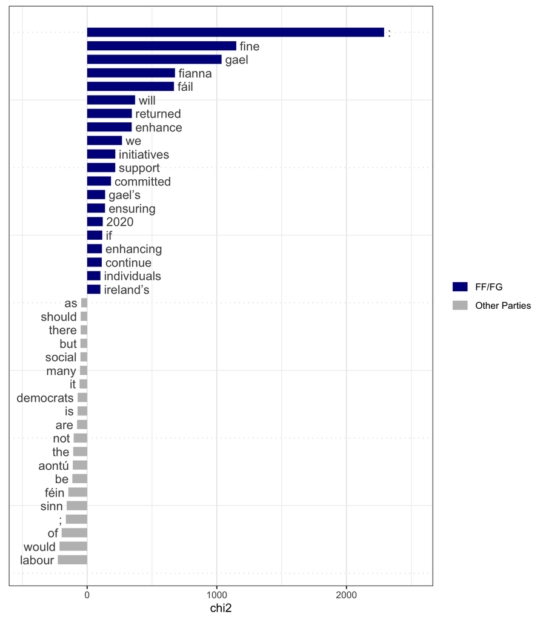

```r
library(quanteda.textplots)

# Run a keyness analysis
keyness_result <- textstat_keyness(dfm_grouped, target = "FF/FG")

# Plot the keyness result
textplot_keyness(keyness_result, n = 20)
```